# White Wine Quality Between Harmfulness and Benefit By Exploring Physicochemical Properties Data

```
##
##  Pearson's product-moment correlation
##
## data:  white_wine$total.sulfur.dioxide and white_wine$alcohol
## t = -35.15, df = 4896, p-value < 2.2e-16
## alternative hypothesis: true correlation is not equal to 0
## 95 percent confidence interval:
##  -0.4709775 -0.4262443
## sample estimates:
##        cor
## -0.4488921
```

Alcohol has bad effects on Liver. However, sulfur dioxide has cardiovascular benefits. They have negative correlation, **what a strange coincidence!**

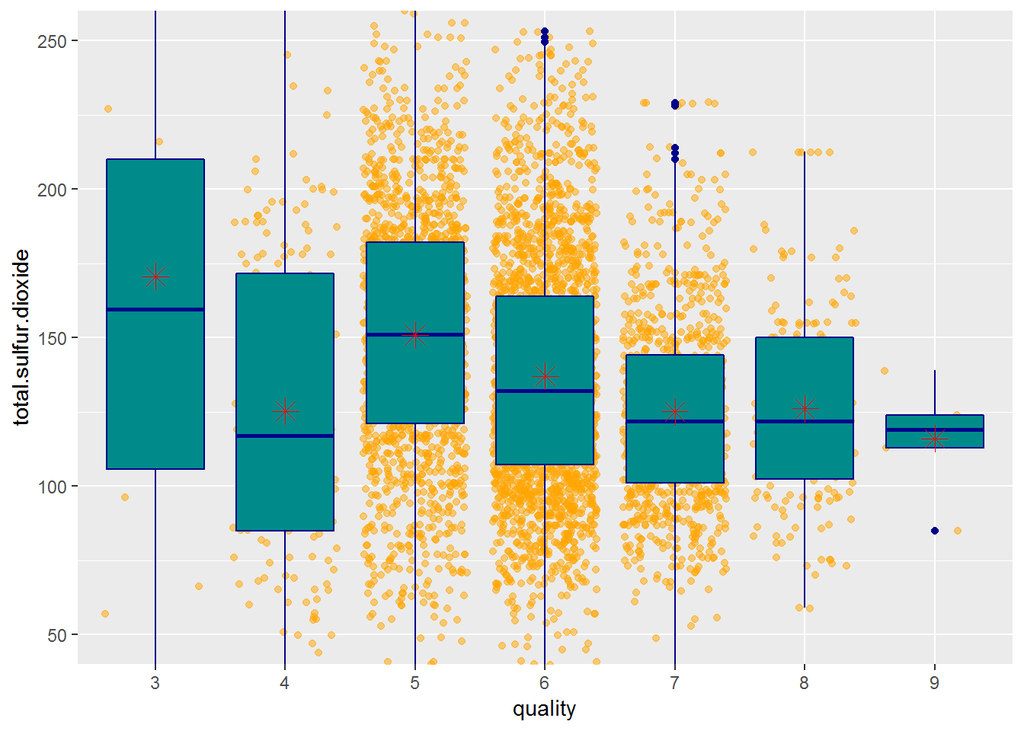

```
## white_wine$quality: 3
##    Min. 1st Qu.  Median    Mean 3rd Qu.    Max.
##    19.0   105.8   159.5   170.6   210.0   440.0
## --------------------------------------------------------
## white_wine$quality: 4
##    Min. 1st Qu.  Median    Mean 3rd Qu.    Max.
##    10.0    85.0   117.0   125.3   171.5   272.0
## --------------------------------------------------------
## white_wine$quality: 5
##    Min. 1st Qu.  Median    Mean 3rd Qu.    Max.
##     9.0   121.0   151.0   150.9   182.0   344.0
## --------------------------------------------------------
## white_wine$quality: 6
##    Min. 1st Qu.  Median    Mean 3rd Qu.    Max.
##    18.0   107.2   132.0   137.0   164.0   294.0
## --------------------------------------------------------
## white_wine$quality: 7
##    Min. 1st Qu.  Median    Mean 3rd Qu.    Max.
##    34.0   101.0   122.0   125.1   144.2   229.0
## --------------------------------------------------------
## white_wine$quality: 8
##    Min. 1st Qu.  Median    Mean 3rd Qu.    Max.
##    59.0   102.5   122.0   126.2   150.0   212.5
## --------------------------------------------------------
## white_wine$quality: 9
##    Min. 1st Qu.  Median    Mean 3rd Qu.    Max.
##      85     113     119     116     124     139
```

Here a slight correlation can be seen, Overall quality increases as total sulfur dioxide decreases, except scores 3 and 4 with least wines. It is strange that as the sulfur dioxide decreases the quality increases which **makes me sure that** **quality does not depend on scientific measurements** because if it depends on scientific measurements it may make the quality increase with sulfur dioxide (or at least like the rate of increase in alcohol with quality) because sulfur dioxide has some health benefits.

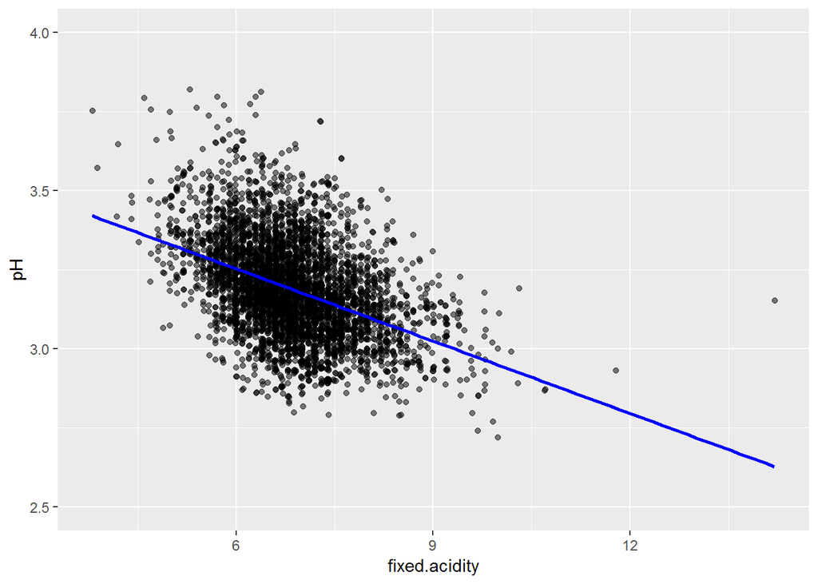

```
##
##  Pearson's product-moment correlation
##
## data:  white_wine$fixed.acidity and white_wine$pH
## t = -32.934, df = 4896, p-value < 2.2e-16
## alternative hypothesis: true correlation is not equal to 0
## 95 percent confidence interval:
##  -0.4485154 -0.4026542
## sample estimates:
##        cor
## -0.4258583
```

The fixed acidity concentration shows negative moderate correlation with pH.

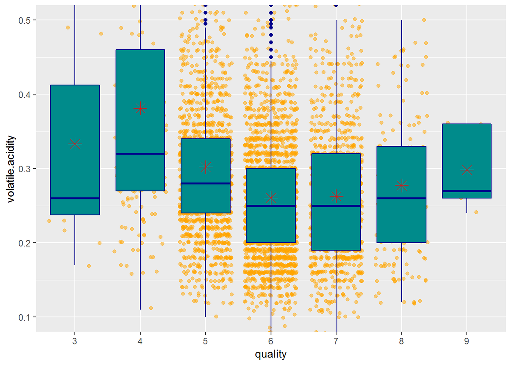

The wine quality increases when volatile acidity decreases, this is what I expected because when (volatile acidity) increases it can lead to an unpleasant, vinegar taste.

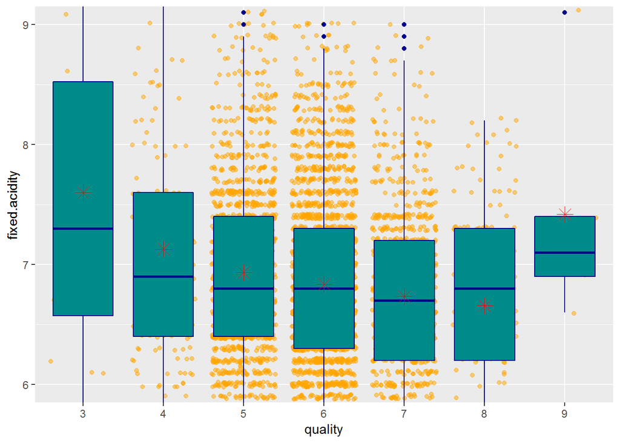

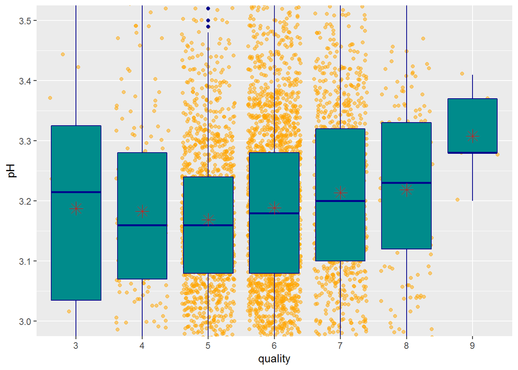

Except for wines with quality score 3, the median pH increases (Acidity decreases) along with quality score. So, from the last three visualizations I conclude that as acidity decreases ‘quality’ increases.

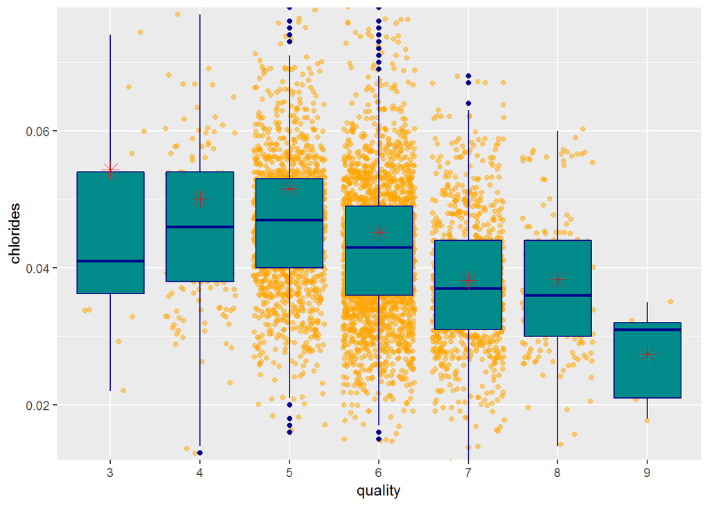

The wine quality increases when chlorides decrease.

# Bivariate Analysis

### Talk about some of the relationships you observed in this part of the investigation. How did the feature(s) of interest vary with other features in the dataset?

I found ‘quality’ has positive moderate correlation with ‘alcohol’ and I found also ‘quality’ has negative correlation with ‘residual.sugar’, **I found these** **results make sense because fermentation process is the conversion of sugar to** **alcohol so sugar and alcohol have negative correlation.** ‘quality’ has negative correlation with density. I found also that ‘quality’ has negative correlation with total sulfur dioxide which **makes me observe that ‘quality’ rating is not based on the healthy** **components (like sulfur dioxide).** There are 3 variables to represent acidity quantity (pH, fixed acidity and volatile acidity) both fixed acidity and volatile acidity have negative correlation with ‘quality’ and pH has positive correlation (acidity decreases) with ‘quality’, so the 3 variables say the quality has negative correlation with acidity. Finally I found also ‘quality’ has negative correlation with chlorides.

### Did you observe any interesting relationships between the other features (not the main feature(s) of interest)?

One of the exciting relationships that I found is alcohol has negative correlation with total sulfur dioxide which **may mean as the healthy components** **(sulfur dioxide) increases the harmful components (alcohol) decreases.** Residual sugar has negative correlation with alcohol due to fermentation process as explained before. pH has negative correlation with fixed acidity and volatile acidity and this is expected because **pH scale decreases as acidity increases.** Also I found density has negative correlation with alcohol and positive correlation with sugar and this is expected as sugar is always decreases as alcohol increases (Fermentation).

```
##
##    3    4    5    6    7    8    9
##   20  163 1457 2198  880  175    5
```

**Hint:** The ‘quality’ (3, 4, 8 and 9) scores (as shown in the last cell) has so small number of data points compared to the other scores which gives inaccurate trending results in almost all the boxplots of the last section and also they became too much sensitive to outliers so not showing the right trend of data.

### What was the strongest relationship you found?

- density has strong negative correlation with alcohol (-0.7801376)
- density has strong positive correlation with sugar ( 0.8389665)

# Multivariate Plots Section

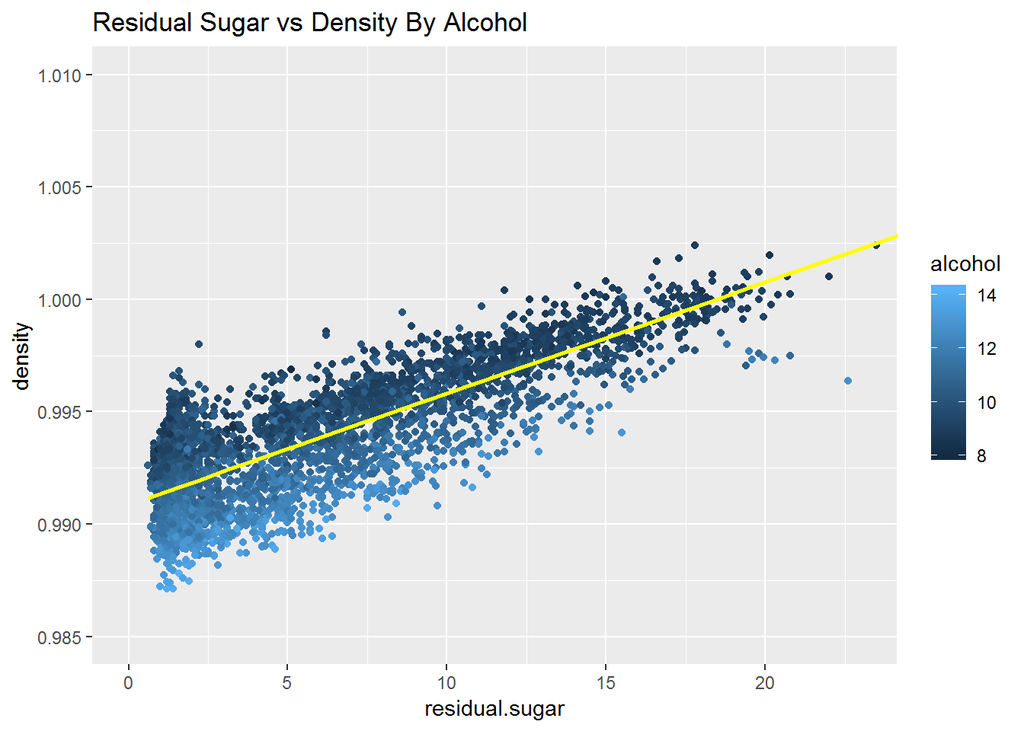

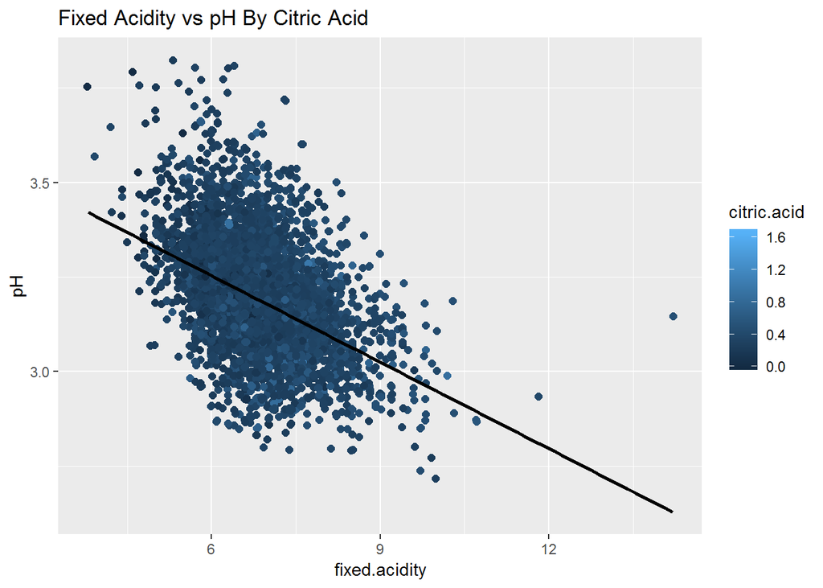

The plot shows a moderate negative correlation between (pH and fixed.acidity) and this is expected because pH is a measure for acidity (pH decreases as acidity increases). I can justify the gathering of the data points in this specific area and not spread because **most wines are between 3-4 on the pH** **scale.** Finally I observed that citric acid has no clear trend which means that it has no significant effect on pH of wine.

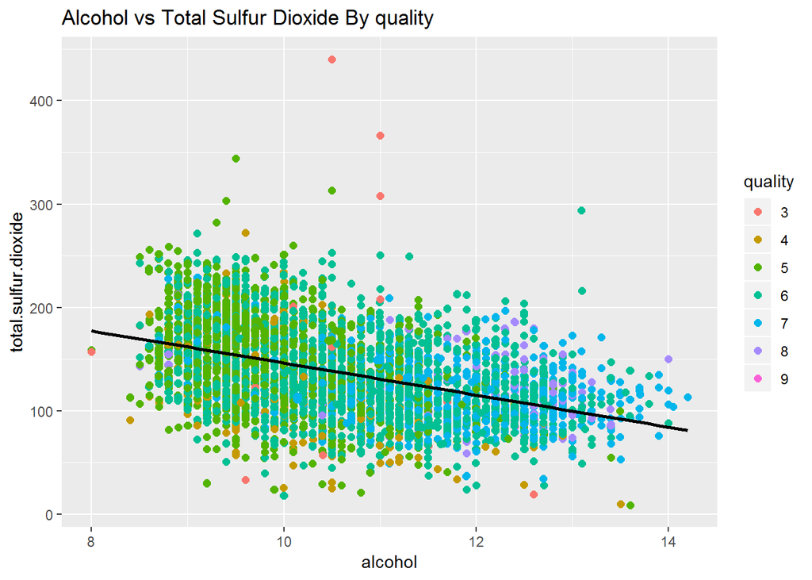

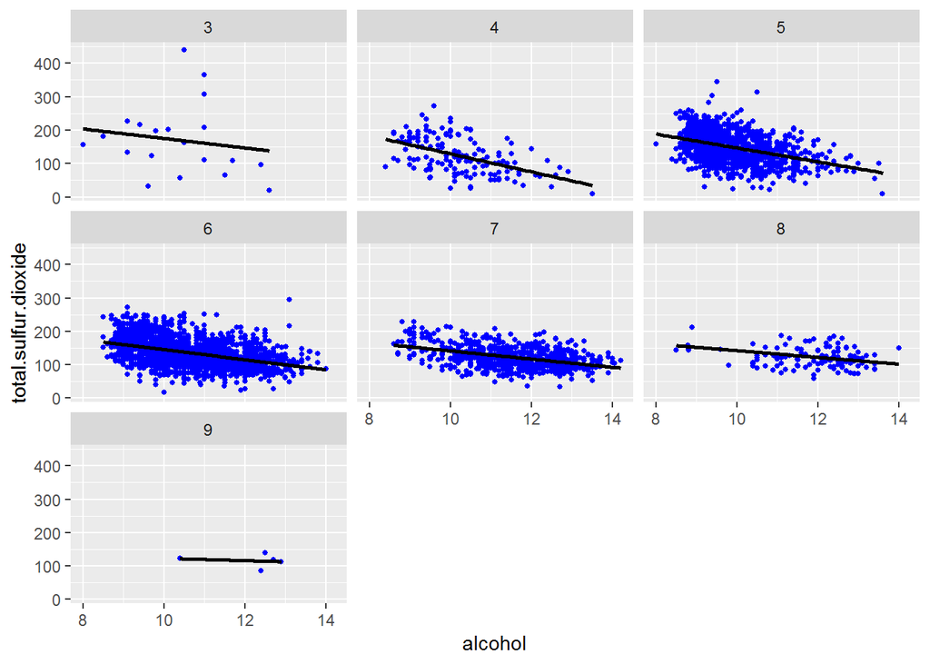

The 2 plots show a moderate negative correlation (-0.45) between (Total sulfur dioxide and alcohol). Generally, I noticed the spread of the green and blue colors among the data points which represent quality scores (5,6 and 7) and this observation makes sense as in the quality variable distribution big number of data points are in scores (5,6 and 7) and if the other scores (3, 4, 8 and 9) have also a big number of data points we could have captured a more clear trend of quality scores than the shown plot. Finally, the captured trend of quality score is as the alcohol increases the quality score increases but total sulfur dioxide decreases.

# Multivariate Analysis

### Talk about some of the relationships you observed in this part of the investigation. Were there features that strengthened each other in terms of looking at your feature(s) of interest?

From (Residual Sugar vs density by alcohol) plot I observed strong positive correlation between (sugar and density) while alcohol decreases as density increases. Also in (Acidity variables) I observed a moderate negative correlation between (pH and fixed.acidity). Finally, a moderate negative correlation between (Total sulfur dioxide and alcohol) and positive correlation between (alcohol and quality).

### Were there any interesting or surprising interactions between features?

The negative correlation between (Total sulfur dioxide and alcohol) which shows the conflict and the trade-off between the healthy components (Total sulfur dioxide) and the harmful components (alcohol).

# Final Plots and Summary

### Plot One

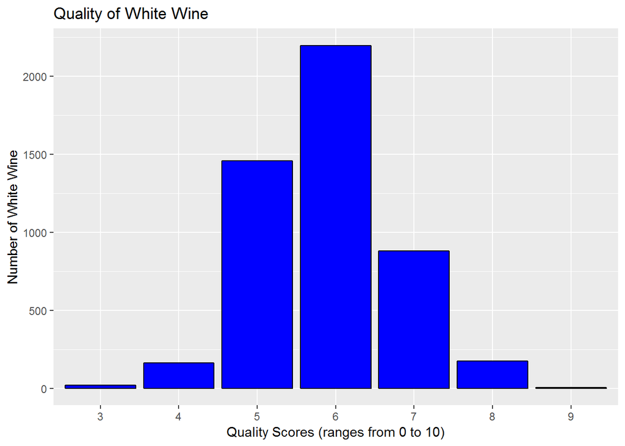

### Description One

The quality variable is the main feature of concern in my analysis. The distribution of quality scores is normal. Not distributing the data uniformly makes some difficulties in data analysis and not capturing clear trends. Also there are only about 5000 data points representing the white wine data which are not large enough data points to get a strong analysis.

### Plot Two

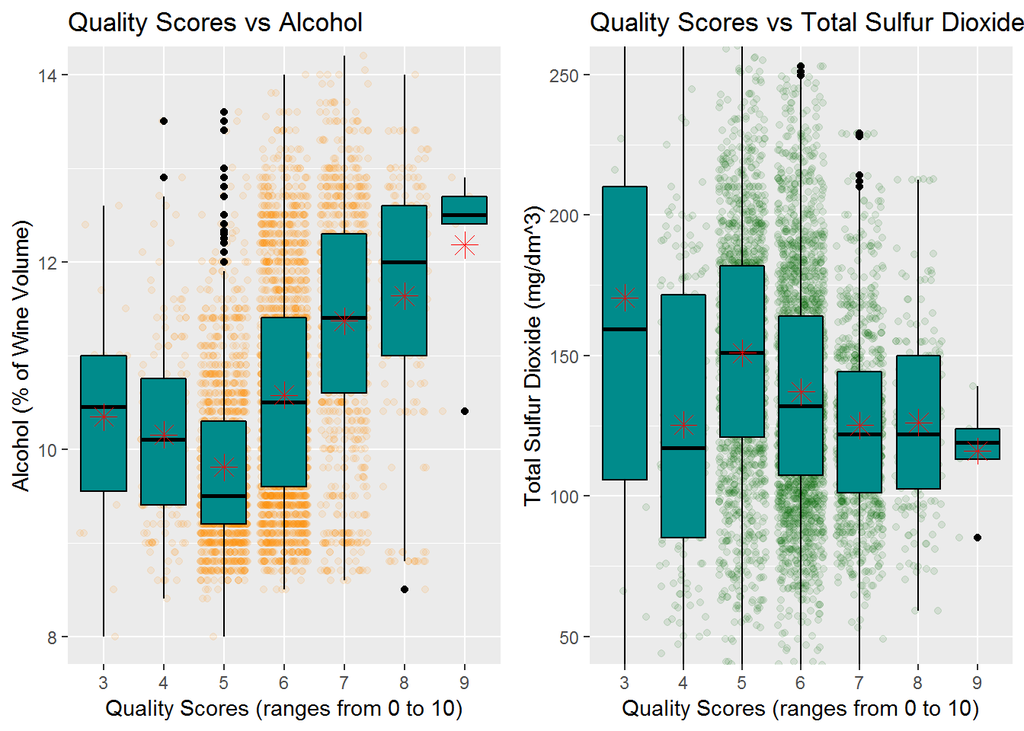

### Description Two

Here, this is the most exciting result to me which is the trade-off between Alcohol (as a harmful component) and Total Sulfur Dioxide (as a healthy component) which gives me impression that there must be a balanced quantities for both of them to reach the maximum possible benefit and the minimum possible harmful effects. Therefore, according to my readings the weekly healthy dose of drinking wine is 6 cups per week which can minimize the harmful effects as much as possible and to try to benefit from it.

### Plot Three

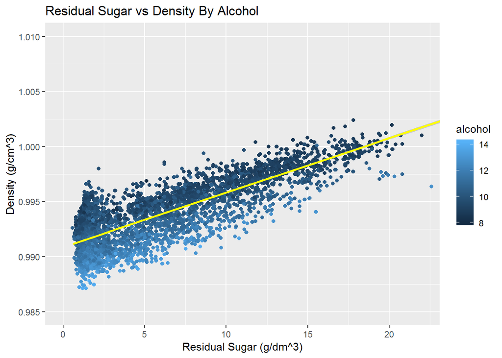

### Description Three

From this plot I can conclude that as sugar increases alcohol decreases which shows that some people prefer high levels of sugar and the other people prefer low levels of sugar and according to my readings the manufacturers take this point in consideration during fermentation process so it needs accurate tools.

# Reflection

Beside data analysis I made a lot of exploration and reading about the wine components and types to be able to describe the relations between variables and to determine the main features of concern during analysis that was because in my culture drinking wine is not popular among people and also it is known that wine has harmful effects more than its benefits, so I was excited to check this by myself through data analysis. The surprising result I concluded was that as the harmful components (alcohol) increases the healthy components (total sulfur dioxide) decreases. The struggles that I faced is the relatively low number of data points, so capturing trends among the variables was not an easy task. In the future I am so interested to repeat this analysis if there are dataset available with large number of data points.

# References:

Readings: White wine: https://en.wikipedia.org/wiki/White_wine https://www.spiritswinecellar.com/components-of-wine/

Coding: https://stackoverflow.com/questions/34617883/how-to-remove-multiple-columns-in- r-dataframe https://stackoverflow.com/questions/31165015/how-to-convert-integer-to- factor-in-r https://stackoverflow.com/questions/6557977/how-do-i-add-the-mean-value-to- a-histogram-in-r https://rstudio-pubs-static.s3.amazonaws.com/240657_5157ff98e8204c358b2118fa69162e18.html